# PCA Analysis of Food Group Nutrient Content

Margaret Hammond

2/16/2022

### Wrangle the Data

```r
nutrients <- read_csv(here('data', 'usda_nutrients.csv')) %>%
  clean_names() %>%
    filter(food_group %in% c('Dairy and Egg Products', 'Fast Foods', 'Nut and Seed Products', 'Snacks', 'Vegetable and Vegetable Products')) ### chose these as my independent variables

nutrients_pca <- nutrients %>%
  select(energy_kcal, protein_g, fat_g, carb_g)  %>% ### chose these as my dependent variables
  scale() %>% ### scale so that all variable are within the same log base
  prcomp()
```

### Biplot

Create a biplot of the trends of the dependent variables, compare these dependent variable relationships to the independent variables by classifying the independent variables groups by coloring.

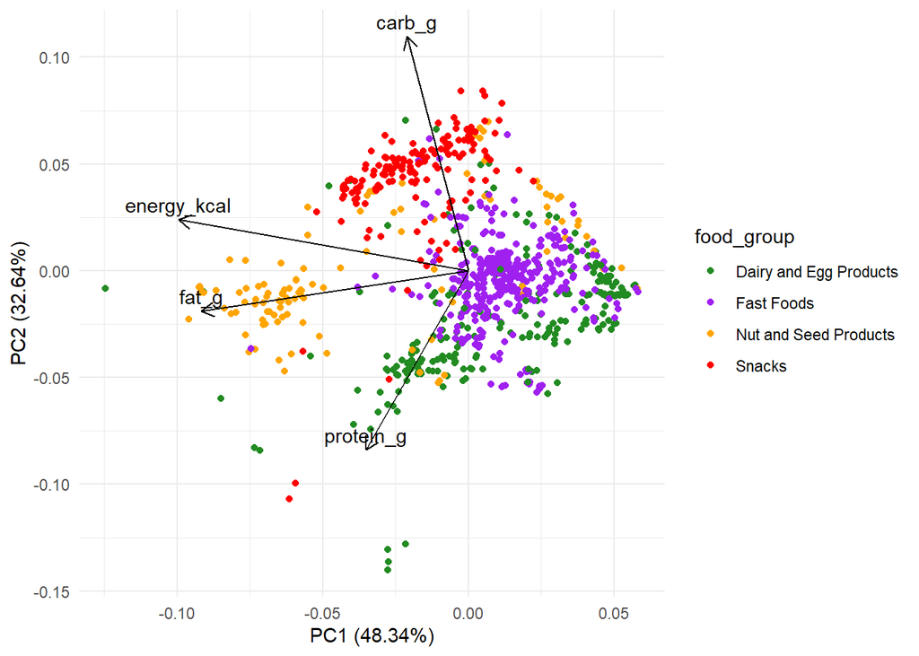

```r
autoplot(nutrients_pca,
         data = nutrients,
         loadings = TRUE,
         colour = "food_group",
         loadings.label = TRUE,
         loadings.colour = 'black',
         loadings.label.colour = 'black',
         loadings.label.vjust = -0.5) +
  scale_color_manual(values = c('forestgreen', 'purple', 'orange', 'red')) +
  scale_fill_manual(values = c()) +
  theme_minimal()
```

### PCA Analysis

From the PCA above, we can learn the following things: - grams of carbs and grams of fat have no relationship - grams of fat and energy kcals are positively correlated - grams of cards and grams of proteins are negatively correlated - Out of all the food groups, Snacks tend to have on average the highest grams of carbs. - Out of all the food groups, Nut and Seed products tend to have on average the highest grams of fat.

### Citation

U.S. Department of Agriculture, Agricultural Research Service. FoodData Central, 2019. fdc.nal.usda.gov.